Import data

```r
library(ggplot2)
library(RColorBrewer)

data1 <- readRDS("summarySCC_PM25.rds")
data2 <- readRDS("Source_Classification_Code.rds")
```

Have total emissions from PM2.5 decreased in the United States from 1999 to 2008? Make a plot showing the total PM2.5 emission from all sources for each of the years 1999, 2002, 2005, and 2008.

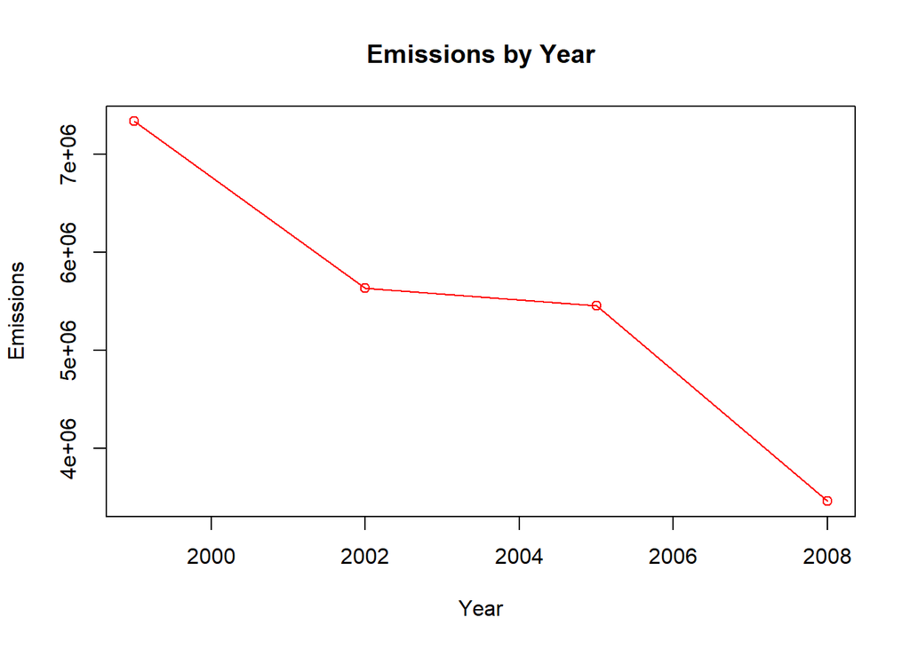

```r
t <- aggregate(Emissions ~ year, data1, sum)

plot(t$year, t$Emissions, type = "o", col = "red", main = "Emissions by Year", ylab = "Emissions", xlab = "Year")
```

Have total emissions from PM2.5 decreased in the Baltimore City, Maryland (fips == “24510”) from 1999 to 2008?

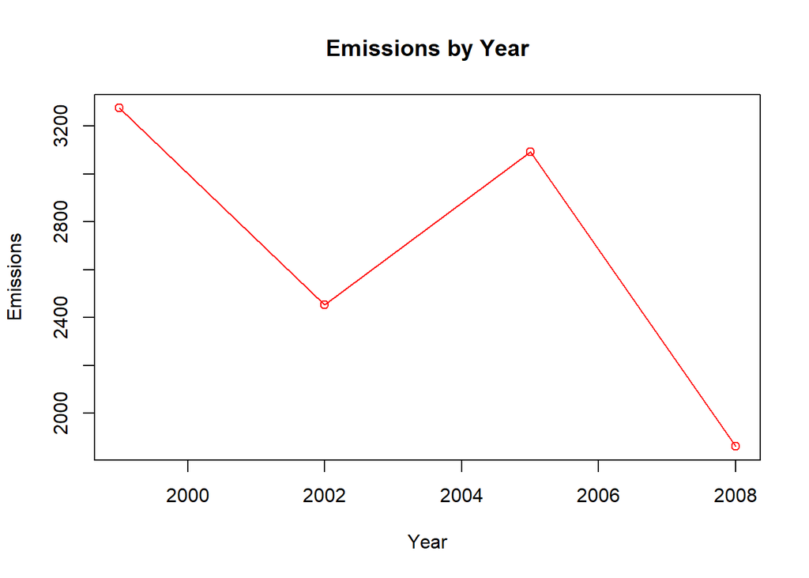

```r
b <- subset(data1, data1$fips == "24510")

t <- aggregate(Emissions ~ year, b, sum)

plot(t$year, t$Emissions, main = "Emissions by Year", type="o", xlab = "Year", ylab = "Emissions", col = "red")
```

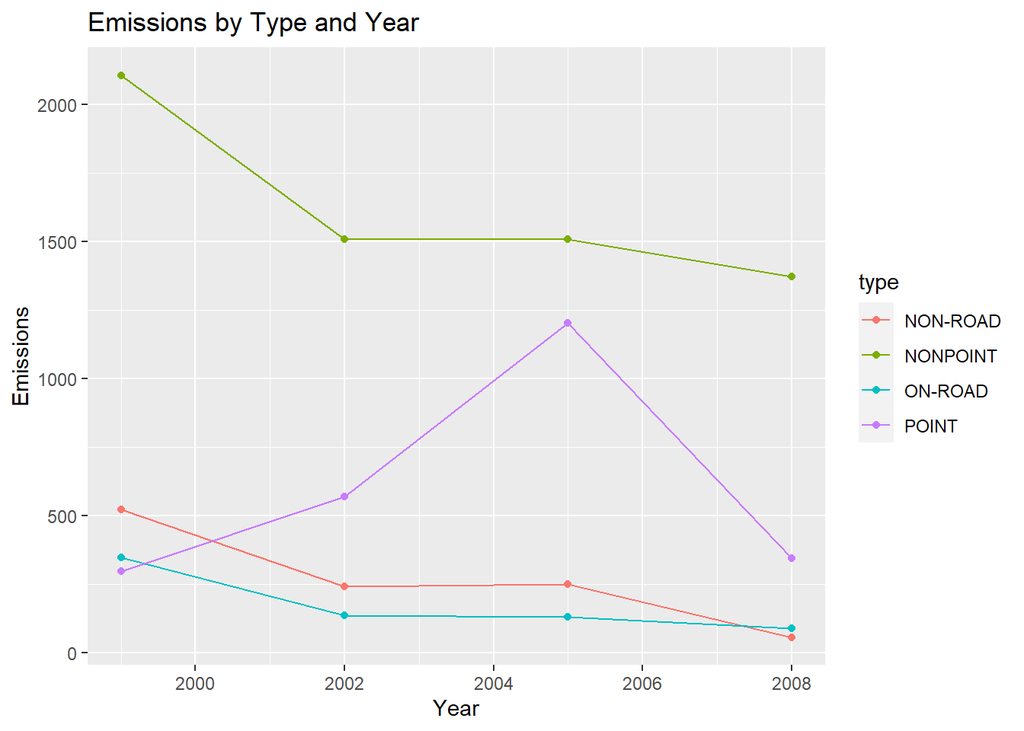

```r
b <- subset(data1, data1$fips == "24510")
b1 <- aggregate(Emissions ~ year + type, b, sum)

ggplot(b1, aes(year, Emissions, col = type)) +
      geom_line() +
      geom_point() +
      ggtitle("Emissions by Type and Year") +
      ylab("Emissions") +
      xlab("Year")
```

Across the United States, how have emissions from coal combustion-related sources changed from 1999–2008?

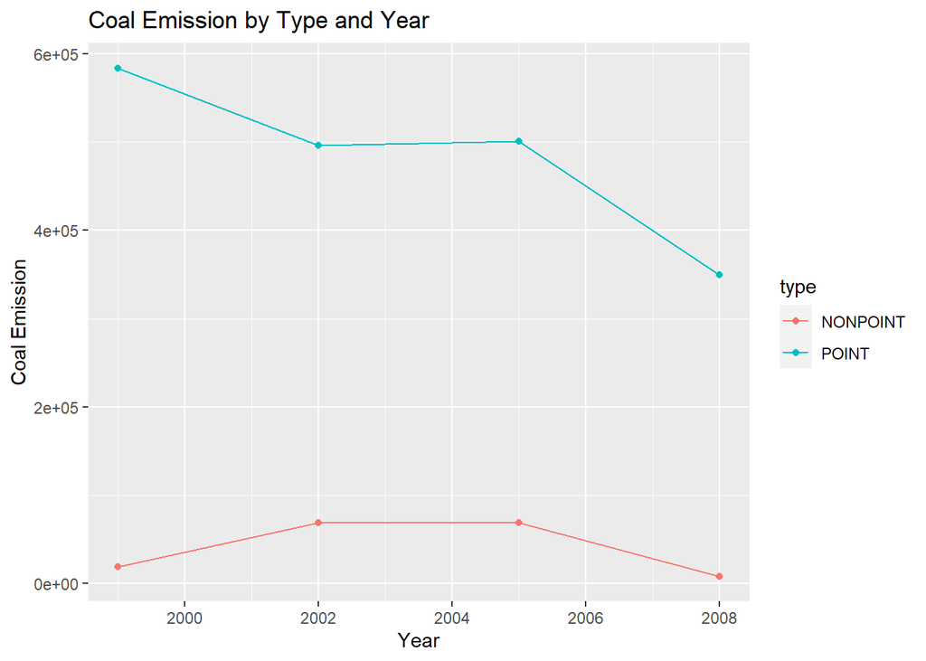

```r
data2Coal <- data2[grepl("coal", data2$Short.Name, ignore.case = T),]
data1Coal <- data1[data1$SCC %in% data2Coal$SCC,]
totalCoal <- aggregate(Emissions ~ year + type, data1Coal, sum)

ggplot(totalCoal, aes(year, Emissions, col = type)) +
      geom_line() +
      geom_point() +
      ggtitle("Coal Emission by Type and Year") +
      xlab("Year") +
      ylab("Coal Emission")
```

How have emissions from motor vehicle sources changed from 1999–2008 in Baltimore City (EI.Sector starts from “Mobile”)?

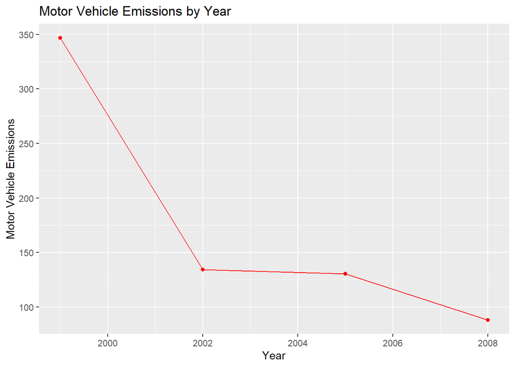

```r
b <- subset(data1, data1$fips == "24510" & data1$type == "ON-ROAD")
b1 <- aggregate(Emissions ~ year, b, sum)

ggplot(b1, aes(year, Emissions)) +
      geom_line(col = "red") +
      geom_point(col = "red") +
      ggtitle("Motor Vehicle Emissions by Year") +
      xlab("Year") +
      ylab("Motor Vehicle Emissions")
```

Compare emissions from motor vehicle sources in Baltimore City with emissions from motor vehicle sources in Los Angeles County, California (fips == “06037”). Which city has seen greater changes over time in motor vehicle emissions?

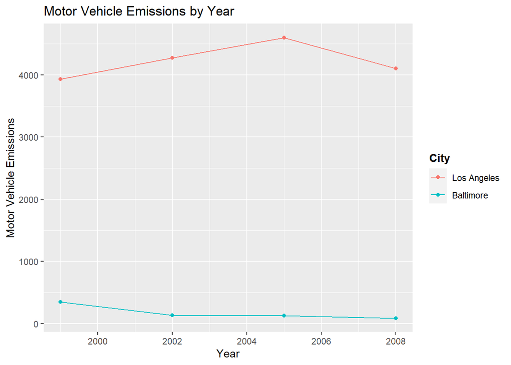

```r
b <- subset(data1, data1$fips %in% c("24510","06037") & data1$type == "ON-ROAD")
b1 <- aggregate(Emissions ~ year + fips, b, sum)

ggplot(b1, aes(year, Emissions, col = fips)) +
      geom_line() +
      geom_point() +
      ggtitle("Motor Vehicle Emissions by Year") +
      labs(x = "Year", y = "Motor Vehicle Emissions") +
      scale_colour_discrete(name = "City", labels = c("Los Angeles", "Baltimore")) +
      theme(legend.title = element_text(face = "bold"))
```